# covid19_spread

2025-11-15

### Team members

- **Bohdan Zasymovych**
- **Solomiia Gadiichuk**
- **Iryna Svyrydenko**

## Statistical Analysis of COVID-19 Spread

### Aim

The aim of this project is to analyze open data on COVID-19. In particular, we aim to test whether vaccination reduces death rates and whether a higher average age of the population in a country is associated with a higher total number of deaths.

## Dataset description

For this we are using the dataset from the collection of the COVID-19 data maintained by Our World in Data (https://github.com/owid/covid-19-data/tree/master). The data is gathered from official resources (national governments and ministries of Health, worldwide organizations (UN, WHO).

We decided to investigate the connection between vaccination and mortality.

For this we are using such random variables:

- `new_cases_smoothed_per_million` - new confirmed cases of COVID-19 (7-day smoothed) per 1,000,000 people;
- `new_deaths_smoothed_per_million` - new deaths attributed to COVID-19 (7-day smoothed) per 1,000,000 people;
- `people_fully_vaccinated_per_hundred` - total number of people who received all doses prescribed by the initial vaccination protocol per 100 people in the total population;
- `total_deaths_per_million` - total deaths attributed to COVID-19 per 1,000,000 people. Counts can include probable deaths, where reported;
- `aged_65_older` - share of population that is 65 years and older, most recent year available;
- `date` - date of observation;
- `location` - name of a country or of a region
- `iso_code` - universal iso code of a country

### Handling of the missing data in the dataser

Missing data in columns corresponding to new cases and deaths was already handled by the authors of the dataset. To create smoothed columns, a 7-day rolling average was used. A 7-day rolling average is calculated for each day using data from that day and the previous six days. If the current day’s value is missing, the average is computed from the available data within that window. This helps handle missing data and reduce artificial spikes (for example, fewer cases may be reported on weekends, while on Monday cases from the weekend are reported, creating a spike).

## Data preparation for visualization

```r
df <- read.csv("owid-covid-data.csv")
```

```r
selected_countries <- c("World", "United States", "India", "Sweden", "Kenya", "Brazil")

df_filtered <- df[df$location %in% selected_countries, ]

df_small <- df_filtered[, c(
  "date",
  "location",
  "new_cases_smoothed_per_million",
  "new_deaths_smoothed_per_million",
  "people_fully_vaccinated_per_hundred",
  "total_deaths_per_million"
)]
df_small$date <- as.Date(df_small$date)
kable(head(df_small, 10), caption = "Preview of Filtered COVID-19 Data")
```

Preview of Filtered COVID-19 Data

|  | date | location | new_cases_smoothed_per_million | new_deaths_smoothed_per_million | people_fully_vaccinated_per_hundred | total_deaths_per_million |
| --- | --- | --- | --- | --- | --- | --- |
| 50235 | 2020-01-05 | Brazil | NA | NA | NA | 0 |
| 50236 | 2020-01-06 | Brazil | NA | NA | NA | 0 |
| 50237 | 2020-01-07 | Brazil | NA | NA | NA | 0 |
| 50238 | 2020-01-08 | Brazil | NA | NA | NA | 0 |
| 50239 | 2020-01-09 | Brazil | NA | NA | NA | 0 |
| 50240 | 2020-01-10 | Brazil | 0 | 0 | NA | 0 |
| 50241 | 2020-01-11 | Brazil | 0 | 0 | NA | 0 |
| 50242 | 2020-01-12 | Brazil | 0 | 0 | NA | 0 |
| 50243 | 2020-01-13 | Brazil | 0 | 0 | NA | 0 |
| 50244 | 2020-01-14 | Brazil | 0 | 0 | NA | 0 |

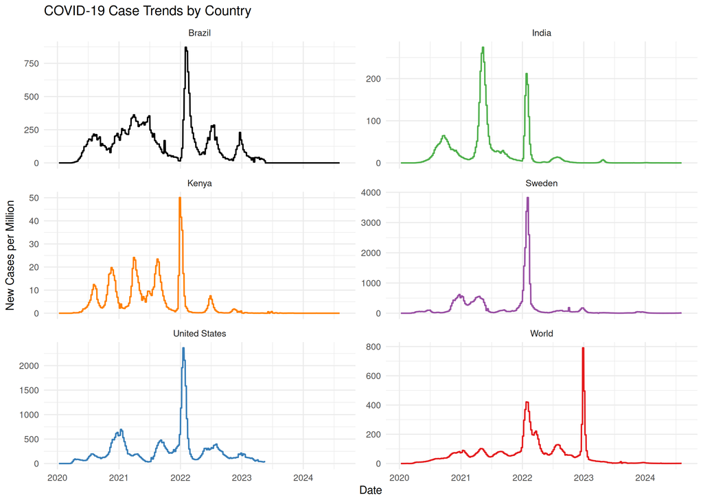

```r
ggplot(df_small, aes(x = date,
                        y = new_cases_smoothed_per_million,
                        color = location)) +
  geom_line(linewidth = 1, na.rm = TRUE) +
    scale_color_manual(values = c(
    "World" = "#E41A1C",
    "United States" = "#377EB8",
    "India" = "#4DAF4A",
    "Sweden" = "#984EA3",
    "Kenya" = "#FF7F00",
    "Brazil" = "black"
  )) +

  facet_wrap(~location, scales = "free_y", ncol = 2) +
  theme_minimal(base_size = 16) +
  labs(title = "COVID-19 Case Trends by Country",
       x = "Date",
       y = "New Cases per Million",
       color = "Country") +
  theme(legend.position = "none")
```

This graph shows change of the `new_cases_smoothed_per_milion` random variable with time for 5 chosen country and a world.

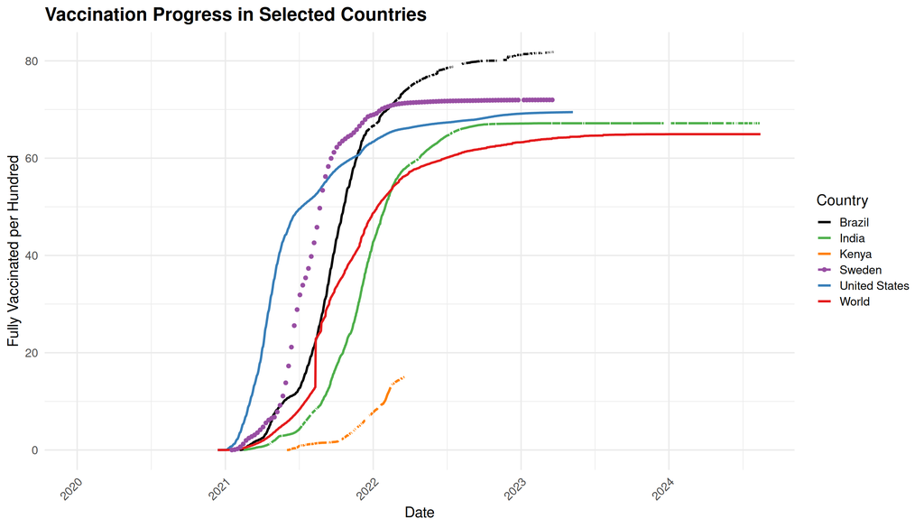

```r
ggplot(df_small, aes(x = date,
                     y = people_fully_vaccinated_per_hundred,
                     color = location)) +
  geom_line(linewidth = 1.2) +
  geom_point(data = subset(df_small, location %in% c("Sweden","Congo")),
             aes(x = date, y = people_fully_vaccinated_per_hundred),
             size = 1.5, na.rm = TRUE) +
  scale_color_manual(values = c(
    "World" = "#E41A1C",
    "United States" = "#377EB8",
    "India" = "#4DAF4A",
    "Sweden" = "#984EA3",
    "Kenya" = "#FF7F00",
    "Brazil" = "black"
  )) +
  theme_minimal(base_size = 16) +
  labs(title = "Vaccination Progress in Selected Countries",
       x = "Date",
       y = "Fully Vaccinated per Hundred",
       color = "Country") +
  theme(
    plot.title = element_text(face = "bold", size = 20),
    axis.text.x = element_text(angle = 45, hjust = 1)
  )
```

This graph shows change of the `people_fully_vaccinated_per_hundred` random variable with time for 5 chosen country and a world.

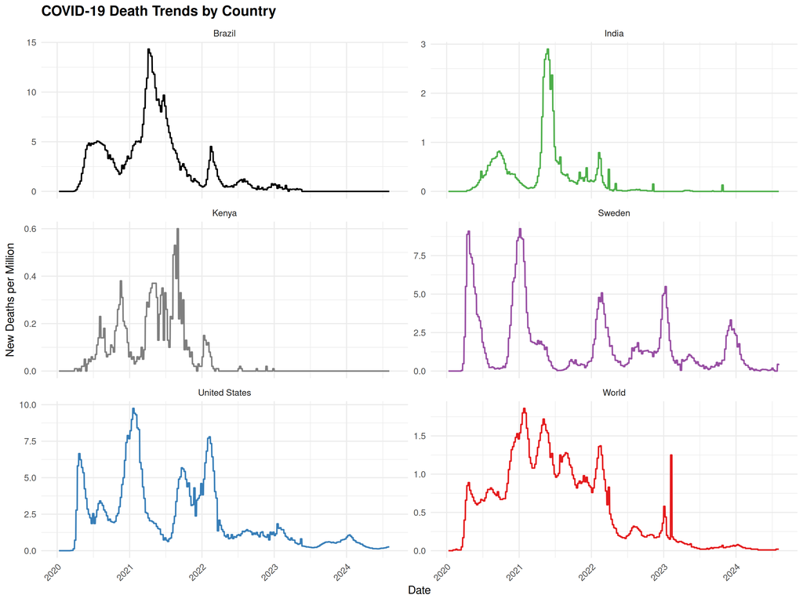

```r
ggplot(df_small, aes(x = date,
                     y = new_deaths_smoothed_per_million,
                     color = location)) +
  geom_line(size = 1, na.rm = TRUE) +
  facet_wrap(~ location, scales = "free_y", ncol = 2) +
  theme_minimal(base_size = 16) +
    scale_color_manual(values = c(
    "World" = "#E41A1C",
    "United States" = "#377EB8",
    "India" = "#4DAF4A",
    "Sweden" = "#984EA3",
    "Congo" = "#FF7F00",
    "Brazil" = "black"
  )) +
  labs(
    title = "COVID-19 Death Trends by Country",
    x = "Date",
    y = "New Deaths per Million"
  ) +
  theme(
    legend.position = "none",
    plot.title = element_text(face = "bold", size = 20),
    axis.text.x = element_text(angle = 45, hjust = 1)
  )
```

This graph shows change of the `new_deaths_smoothed_per_million` random variable with time for 5 chosen country and a world.

```r
date <- "2021-08-01"
target_date <- as.Date(date)

snapshot <- df %>%
  filter(date == target_date) %>%
  filter(!is.na(people_fully_vaccinated_per_hundred),
         !is.na(new_deaths_smoothed_per_million),
         !location %in% c("World")
  ) %>%
  select(location,
         people_fully_vaccinated_per_hundred,
         new_deaths_smoothed_per_million)

cat("Number of countries with available data for this date: ", length(df))
```

[output not shown]

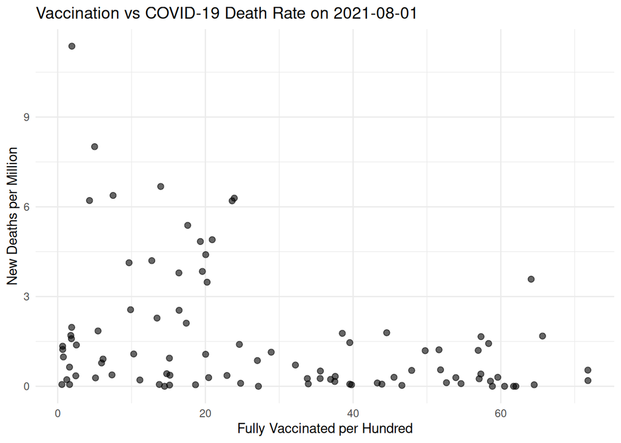

```r
ggplot(snapshot,
       aes(x = people_fully_vaccinated_per_hundred,
           y = new_deaths_smoothed_per_million)) +

  geom_point(alpha = 0.6, size = 2) +
  labs(
    title = paste("Vaccination vs COVID-19 Death Rate on", target_date),
    x = "Fully Vaccinated per Hundred",
    y = "New Deaths per Million"
  ) +
  theme_minimal()
```

On this graph we tried to get initial insight about impact of vaccines on a death rate. Each point represents a country on a specific date (August 1, 2021). The X-axis shows the percentage of the population fully vaccinated `people_fully_vaccinated_per_hundred`, while the Y-axis shows the smoothed number of new deaths per million people `new_deaths_smoothed_per_million`.

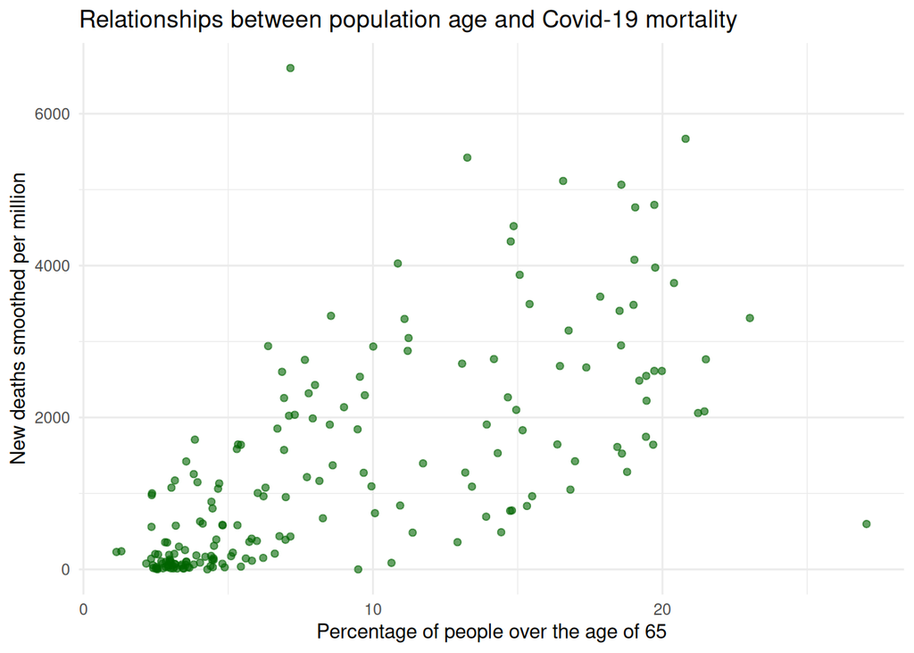

```r
df_hypothesis2 <- df %>%
  filter(!is.na(aged_65_older),
         !is.na(new_deaths_smoothed_per_million),
         !is.na(continent), continent != "") %>%
  group_by(location) %>%
  summarise(
    aged_65_older = max(aged_65_older, na.rm = TRUE),
    total_deaths_per_million = max(total_deaths_per_million, na.rm = TRUE)
  )

ggplot(df_hypothesis2, aes(x = aged_65_older, y = total_deaths_per_million)) +
  geom_point(alpha = 0.6, color = "darkgreen") +
  labs(
    title = "Relationships between population age and Covid-19 mortality",
    x = "Percentage of people over the age of 65",
    y = "New deaths smoothed per million"
  ) +
  theme_minimal()
```

# Insights

# Hypotheses

### Our first hypothesis

From the graph “Vaccination vs COVID-19 Death Rate on 2021-08-01”, we observed that countries with a higher percentage of fully vaccinated people tend to have points closer to the X-axis. Based on this observation, we formulated the following hypothesis to test whether this pattern occurred by chance or there is general trend.

$H_0$: Vaccination rate has no effect on death rate.

$H_1$: Increasing vaccination rate reduces the death rate.

# Testing first hypothesis

## Data preparation for test

Leaving only the required columns and restricting the data to the period from 2021-01-01 to 2021-12-31. This range was chosen because the visualization stage showed that vaccination activity was highest during this interval.

```r
df = df[, c("iso_code", "date", "new_cases_smoothed_per_million", "new_deaths_smoothed_per_million", "people_fully_vaccinated_per_hundred")]

df$date <- as.Date(df$date)
df <- df[df$date >= "2021-01-01" & df$date <= "2021-12-31", ]
```

Filtering the dataset to remove rows with N/As in `new_cases_smoothed_per_million` and `new_deaths_smoothed_per_million`. The dataset also included aggregated world regions, which were excluded except for the overall global entry.

```r
na_counts_list <- as.list(colSums(is.na(df)))
cat("Number of N/A in the original dataset per columns:\n")
```

```
## Number of N/A in the original dataset per columns:
```

```r
na_counts_list
```

```
## $iso_code
## [1] 0
##
## $date
## [1] 0
##
## $new_cases_smoothed_per_million
## [1] 5299
##
## $new_deaths_smoothed_per_million
## [1] 5299
##
## $people_fully_vaccinated_per_hundred
## [1] 61592
```

```r
df_filtered <- df %>%
  filter(!grepl("^OWID_", iso_code) | iso_code == "OWID_WRL")


df_na <- df_filtered %>%
  filter(is.na(new_cases_smoothed_per_million))

bad_iso <- unique(df_na$iso_code)

df_filtered <- df_filtered %>%
  filter(!iso_code %in% bad_iso)

# Country with BES iso code were removed since for some reason data for it still contained single N/A value after filtering
df_filtered <- df_filtered %>%
  filter(!iso_code == "BES")


na_counts_list_filtered <- as.list(colSums(is.na(df_filtered)))
cat("Number of N/A in the filtered dataset per columns:\n")
```

```
## Number of N/A in the filtered dataset per columns:
```

```r
na_counts_list_filtered
```

```
## $iso_code
## [1] 0
##
## $date
## [1] 0
##
## $new_cases_smoothed_per_million
## [1] 0
##
## $new_deaths_smoothed_per_million
## [1] 0
##
## $people_fully_vaccinated_per_hundred
## [1] 56659
```

The column `people_fully_vaccinated_per_hundred` contained missing values because many countries did not report vaccination rates daily. Linear interpolation was applied to fill these gaps, but only for countries where interpolation could provide a reliable estimate. Countries were selected based on their average reporting gap, keeping only those reporting on average at least once every two weeks. After interpolation, values before the first report were set to zero, and values after the last report were filled with the final reported value.

Calculate mean gaps between vaccination reports by countries

```r
threshold_gap_days <- 14

mean_gaps <- df_filtered %>%
  group_by(iso_code) %>%
  filter(!is.na(people_fully_vaccinated_per_hundred)) %>%
  arrange(date) %>%
  mutate(gap = as.numeric(date - lag(date))) %>%
  summarise(mean_gap = mean(gap, na.rm = TRUE), .groups = "drop")

good_countries <- mean_gaps %>%
  filter(mean_gap <= threshold_gap_days) %>%
  pull(iso_code)

df_filtered_vaccinations <- df_filtered %>%
  filter(iso_code %in% good_countries)

head(mean_gaps)
```

```
## # A tibble: 6 × 2
##   iso_code mean_gap
##   <chr>       <dbl>
## 1 ABW          1.30
## 2 AFG         12.8
## 3 AGO          5.95
## 4 AIA         11.0
## 5 ALB          2.02
## 6 AND         12.2
```

Applying linear interpolation

```r
df_interpolated <- df_filtered_vaccinations %>%
  group_by(iso_code) %>%
  arrange(date) %>%

  mutate(
    pvac = na.approx(
      people_fully_vaccinated_per_hundred,
      x = date,
      na.rm = FALSE
    )
  ) %>%

  mutate(first_non_na_index = match(TRUE, !is.na(pvac))) %>%

  mutate(
    pvac = ifelse(row_number() < first_non_na_index, 0, pvac)
  ) %>%

  fill(pvac, .direction = "down") %>%

  mutate(people_fully_vaccinated_per_hundred = pvac) %>%

  select(-pvac, -first_non_na_index) %>%

  ungroup() %>%
  arrange(iso_code, date)
```

```r
na_counts_list_final_filtered <- as.list(colSums(is.na(df_interpolated)))
cat("Number of N/A in the final interpolated dataset per columns:\n")
```

```
## Number of N/A in the final interpolated dataset per columns:
```

```r
na_counts_list_final_filtered
```

```
## $iso_code
## [1] 0
##
## $date
## [1] 0
##
## $new_cases_smoothed_per_million
## [1] 0
##
## $new_deaths_smoothed_per_million
## [1] 0
##
## $people_fully_vaccinated_per_hundred
## [1] 0
```

```r
cat("\n\n")
```

```r
cat("Number of countries/regions before and after filtering:\n")
```

```
## Number of countries/regions before and after filtering:
```

```r
cat("Before: ", length(unique(df$iso_code)), "\n")
```

```
## Before:  254
```

```r
cat("After: ", length(unique(df_interpolated$iso_code)))
```

```
## After:  187
```

```r
head(df_interpolated)
```

```
## # A tibble: 6 × 5
##   iso_code date       new_cases_smoothed_per_million new_deaths_smoothed_per_m…¹
##   <chr>    <date>                              <dbl>                       <dbl>
## 1 ABW      2021-01-01                           138.                        0
## 2 ABW      2021-01-02                           138.                        0
## 3 ABW      2021-01-03                           284.                        2.65
## 4 ABW      2021-01-04                           284.                        2.65
## 5 ABW      2021-01-05                           284.                        2.65
## 6 ABW      2021-01-06                           284.                        2.65
## # ℹ abbreviated name: ¹new_deaths_smoothed_per_million
## # ℹ 1 more variable: people_fully_vaccinated_per_hundred <dbl>
```

After applying all filtering steps, we obtained a dataset without any N/A values and with a reduced number of countries, while still retaining enough for representative results.

# Testing

## Linear regression

For testing we are using simple linear regression on data from single country. `new_deaths_smoothed_per_million` in the equation is dependent variable and `people_fully_vaccinated_per_hundred` - independent.

Equation:

$$Y_t = \beta_0 + \beta_1 X_t + \epsilon$$

Where:  
$Y_t$ - `new_deaths_smoothed_per_million` on day $t$  
$X_t$ - `people_fully_vaccinated_per_hundred` on day $t$  
$\beta_0$ - intercept  
$\beta_1$ - slope, coefficient we are testing for being statistically significantly less than 0  
$\epsilon$ - error term, it captures everything affecting deaths except number of vaccinations: number of cases, seasons, reporting delays, random noise, etc

To conduct a test we are choosing some fixed country and considering number of new deaths and number of vaccinations on each day.

**Hypothesis:**

$H_0$: $\beta_1 = 0$.

$H_1$: $\beta_1 < 0$.

**Estimator for coefficient** $\beta_1$:

$$\hat{\beta}_1 = \frac{\sum_{t=1}^{T} (X_t - \overline{X})(Y_t -
\overline{Y})}{\sum_{t=1}^{T} (X_t - \overline{X})^2}$$

**Estimator for the sum of squared residuals:**

$$\hat{R} = \sum \left( Y_t - \hat{Y_t} \right)^2$$

**Estimator for variance (**$\sigma^2$):

$$\hat{\sigma}^2 = \frac{\hat{R}}{T-2}$$

**Test statistic under** $H_0$:

$$T(\textbf{X}) = \frac{\hat{\beta}_1}{\hat{\sigma}} \sim
\mathcal{T}_{T-2}$$

**Critical region:**

$$C_\alpha = \left \{ \textbf{x} \in R^n \; | \; t(\textbf{x}) <
t_{\alpha} \right \}$$

**Where:**  
$\textbf{x}$ - given sample  
$t(\textbf{x})$ - realization of test statistic for a given sample  
$t_\alpha$ - quantile of t-student distribution of level $\alpha$

For next tests we conducted we are choosing maximal probability of type I error $\alpha=0.01$. If p-value of a test is smaller than $0.01$ we are rejecting $H_0$

Since our model can be applied only for a single country/region we have chosen next: world, USA, India, Sweden, Kenya, Brazil. We were trying to choose countries with different development levels and from different regions to get more reliable insight.

### World

```r
df_country <- subset(df_interpolated, iso_code == "OWID_WRL")

model <- lm(new_deaths_smoothed_per_million ~ people_fully_vaccinated_per_hundred, data=df_country)
print(summary(model))
```

```
##
## Call:
## lm(formula = new_deaths_smoothed_per_million ~ people_fully_vaccinated_per_hundred,
##     data = df_country)
##
## Residuals:
##      Min       1Q   Median       3Q      Max
## -0.36751 -0.12975  0.01676  0.14276  0.42636
##
## Coefficients:
##                                      Estimate Std. Error t value Pr(>|t|)
## (Intercept)                          1.435691   0.014748   97.35   <2e-16 ***
## people_fully_vaccinated_per_hundred -0.012818   0.000629  -20.38   <2e-16 ***
## ---
## Signif. codes:  0 '***' 0.001 '**' 0.01 '*' 0.05 '.' 0.1 ' ' 1
##
## Residual standard error: 0.199 on 363 degrees of freedom
## Multiple R-squared:  0.5336, Adjusted R-squared:  0.5323
## F-statistic: 415.3 on 1 and 363 DF,  p-value: < 2.2e-16
```

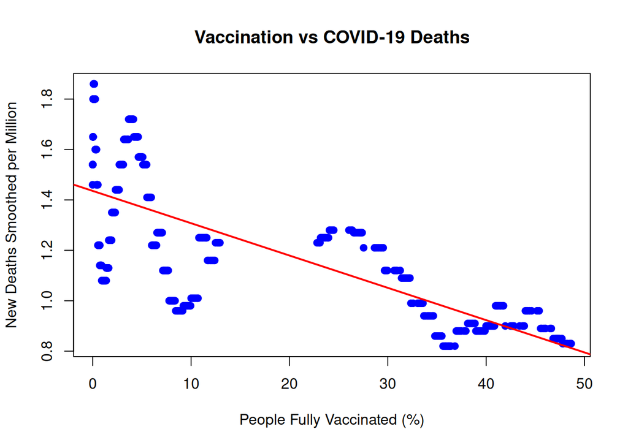

```r
plot(df_country$people_fully_vaccinated_per_hundred,
     df_country$new_deaths_smoothed_per_million,
     xlab = "People Fully Vaccinated (%)",
     ylab = "New Deaths Smoothed per Million",
     main = "Vaccination vs COVID-19 Deaths",
     pch = 19, col = "blue")

# Add regression line
abline(model, col = "red", lwd = 2)
```

Estimated coefficient is less than $0$ ($\approx -0.013$), p-value is significantly smaller than $0.01$ ($\approx <2e-16$). We reject $H_0$.

### United States

```r
df_country <- subset(df_interpolated, iso_code == "USA")

model <- lm(new_deaths_smoothed_per_million ~ people_fully_vaccinated_per_hundred, data=df_country)
print(summary(model))
```

```
##
## Call:
## lm(formula = new_deaths_smoothed_per_million ~ people_fully_vaccinated_per_hundred,
##     data = df_country)
##
## Residuals:
##     Min      1Q  Median      3Q     Max
## -2.8185 -2.1707  0.0336  2.1357  3.3594
##
## Coefficients:
##                                      Estimate Std. Error t value Pr(>|t|)
## (Intercept)                          6.475130   0.235320   27.52   <2e-16 ***
## people_fully_vaccinated_per_hundred -0.067053   0.005205  -12.88   <2e-16 ***
## ---
## Signif. codes:  0 '***' 0.001 '**' 0.01 '*' 0.05 '.' 0.1 ' ' 1
##
## Residual standard error: 2.109 on 363 degrees of freedom
## Multiple R-squared:  0.3138, Adjusted R-squared:  0.3119
## F-statistic:   166 on 1 and 363 DF,  p-value: < 2.2e-16
```

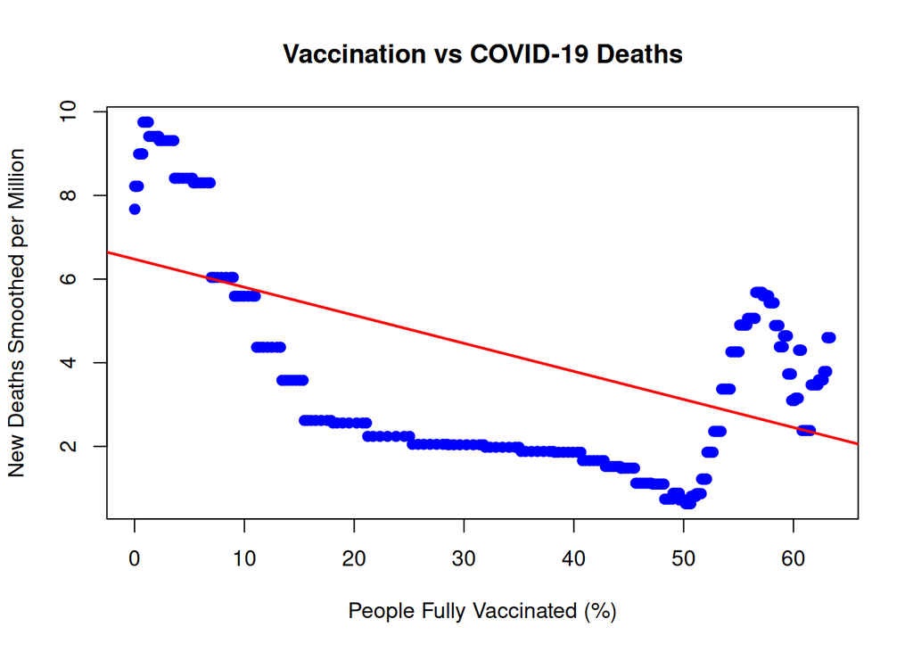

```r
plot(df_country$people_fully_vaccinated_per_hundred,
     df_country$new_deaths_smoothed_per_million,
     xlab = "People Fully Vaccinated (%)",
     ylab = "New Deaths Smoothed per Million",
     main = "Vaccination vs COVID-19 Deaths",
     pch = 19, col = "blue")

# Add regression line
abline(model, col = "red", lwd = 2)
```

Estimated coefficient is less than $0$ ($\approx -0.067$), p-value is significantly smaller than $0.01$ ($\approx <2e-16$). We reject $H_0$.

### India

```r
df_country <- subset(df_interpolated, iso_code == "IND")

model <- lm(new_deaths_smoothed_per_million ~ people_fully_vaccinated_per_hundred, data=df_country)
print(summary(model))
```

```
##
## Call:
## lm(formula = new_deaths_smoothed_per_million ~ people_fully_vaccinated_per_hundred,
##     data = df_country)
##
## Residuals:
##      Min       1Q   Median       3Q      Max
## -0.76255 -0.60264 -0.28724  0.08038  2.13249
##
## Coefficients:
##                                      Estimate Std. Error t value Pr(>|t|)
## (Intercept)                          0.822639   0.054523  15.088  < 2e-16 ***
## people_fully_vaccinated_per_hundred -0.018194   0.003517  -5.173 3.81e-07 ***
## ---
## Signif. codes:  0 '***' 0.001 '**' 0.01 '*' 0.05 '.' 0.1 ' ' 1
##
## Residual standard error: 0.7925 on 363 degrees of freedom
## Multiple R-squared:  0.06866,    Adjusted R-squared:  0.0661
## F-statistic: 26.76 on 1 and 363 DF,  p-value: 3.815e-07
```

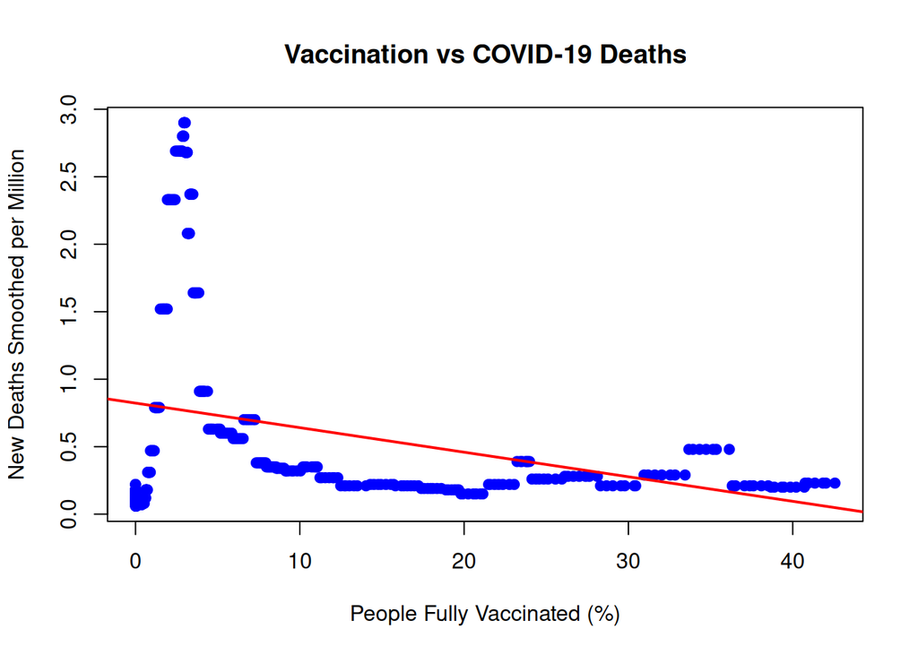

```r
plot(df_country$people_fully_vaccinated_per_hundred,
     df_country$new_deaths_smoothed_per_million,
     xlab = "People Fully Vaccinated (%)",
     ylab = "New Deaths Smoothed per Million",
     main = "Vaccination vs COVID-19 Deaths",
     pch = 19, col = "blue")

# Add regression line
abline(model, col = "red", lwd = 2)
```

Estimated coefficient is less than $0$ ($\approx -0.018$), p-value is significantly smaller than $0.01$ ($\approx 3.81e-07$). We reject $H_0$.

### Sweden

```r
df_country <- subset(df_interpolated, iso_code == "SWE")

model <- lm(new_deaths_smoothed_per_million ~ people_fully_vaccinated_per_hundred, data=df_country)
print(summary(model))
```

```
##
## Call:
## lm(formula = new_deaths_smoothed_per_million ~ people_fully_vaccinated_per_hundred,
##     data = df_country)
##
## Residuals:
##     Min      1Q  Median      3Q     Max
## -1.8724 -1.2553 -0.5345  0.5804  5.9755
##
## Coefficients:
##                                      Estimate Std. Error t value Pr(>|t|)
## (Intercept)                          3.274520   0.149502   21.90   <2e-16 ***
## people_fully_vaccinated_per_hundred -0.052293   0.003605  -14.51   <2e-16 ***
## ---
## Signif. codes:  0 '***' 0.001 '**' 0.01 '*' 0.05 '.' 0.1 ' ' 1
##
## Residual standard error: 1.828 on 363 degrees of freedom
## Multiple R-squared:  0.367,  Adjusted R-squared:  0.3652
## F-statistic: 210.4 on 1 and 363 DF,  p-value: < 2.2e-16
```

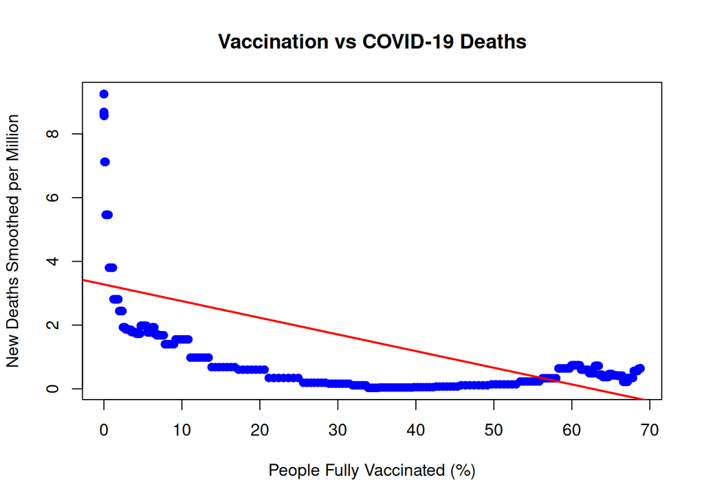

```r
plot(df_country$people_fully_vaccinated_per_hundred,
     df_country$new_deaths_smoothed_per_million,
     xlab = "People Fully Vaccinated (%)",
     ylab = "New Deaths Smoothed per Million",
     main = "Vaccination vs COVID-19 Deaths",
     pch = 19, col = "blue")

# Add regression line
abline(model, col = "red", lwd = 2)
```

Estimated coefficient is less than $0$ ($\approx -0.052$), p-value is significantly smaller than $0.01$ ($\approx <2e-16$). We reject $H_0$.

### Kenya

```r
df_country <- subset(df_interpolated, iso_code == "KEN")

model <- lm(new_deaths_smoothed_per_million ~ people_fully_vaccinated_per_hundred, data=df_country)
print(summary(model))
```

```
##
## Call:
## lm(formula = new_deaths_smoothed_per_million ~ people_fully_vaccinated_per_hundred,
##     data = df_country)
##
## Residuals:
##      Min       1Q   Median       3Q      Max
## -0.19862 -0.09573 -0.01254  0.09758  0.41465
##
## Coefficients:
##                                      Estimate Std. Error t value Pr(>|t|)
## (Intercept)                          0.228624   0.008977  25.468  < 2e-16 ***
## people_fully_vaccinated_per_hundred -0.028851   0.003688  -7.822 5.72e-14 ***
## ---
## Signif. codes:  0 '***' 0.001 '**' 0.01 '*' 0.05 '.' 0.1 ' ' 1
##
## Residual standard error: 0.1386 on 363 degrees of freedom
## Multiple R-squared:  0.1442, Adjusted R-squared:  0.1419
## F-statistic: 61.18 on 1 and 363 DF,  p-value: 5.72e-14
```

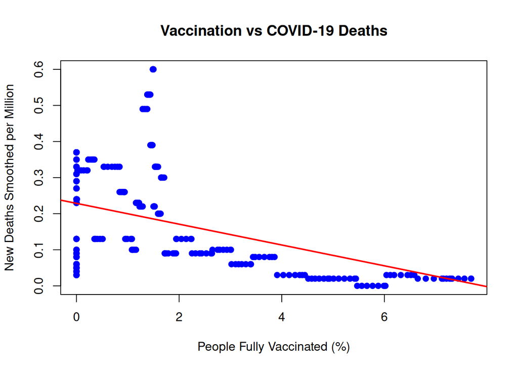

```r
plot(df_country$people_fully_vaccinated_per_hundred,
     df_country$new_deaths_smoothed_per_million,
     xlab = "People Fully Vaccinated (%)",
     ylab = "New Deaths Smoothed per Million",
     main = "Vaccination vs COVID-19 Deaths",
     pch = 19, col = "blue")

# Add regression line
abline(model, col = "red", lwd = 2)
```

Estimated coefficient is less than $0$ ($\approx -0.029$), p-value is significantly smaller than $0.01$ ($\approx 5.72e-14$). We reject $H_0$.

### Brazil

```r
df_country <- subset(df_interpolated, iso_code == "BRA")

model <- lm(new_deaths_smoothed_per_million ~ people_fully_vaccinated_per_hundred, data=df_country)
print(summary(model))
```

```
##
## Call:
## lm(formula = new_deaths_smoothed_per_million ~ people_fully_vaccinated_per_hundred,
##     data = df_country)
##
## Residuals:
##    Min     1Q Median     3Q    Max
## -5.153 -1.429 -0.185  1.540  6.291
##
## Coefficients:
##                                      Estimate Std. Error t value Pr(>|t|)
## (Intercept)                          8.443057   0.194544   43.40   <2e-16 ***
## people_fully_vaccinated_per_hundred -0.124232   0.006038  -20.57   <2e-16 ***
## ---
## Signif. codes:  0 '***' 0.001 '**' 0.01 '*' 0.05 '.' 0.1 ' ' 1
##
## Residual standard error: 2.608 on 363 degrees of freedom
## Multiple R-squared:  0.5383, Adjusted R-squared:  0.5371
## F-statistic: 423.3 on 1 and 363 DF,  p-value: < 2.2e-16
```

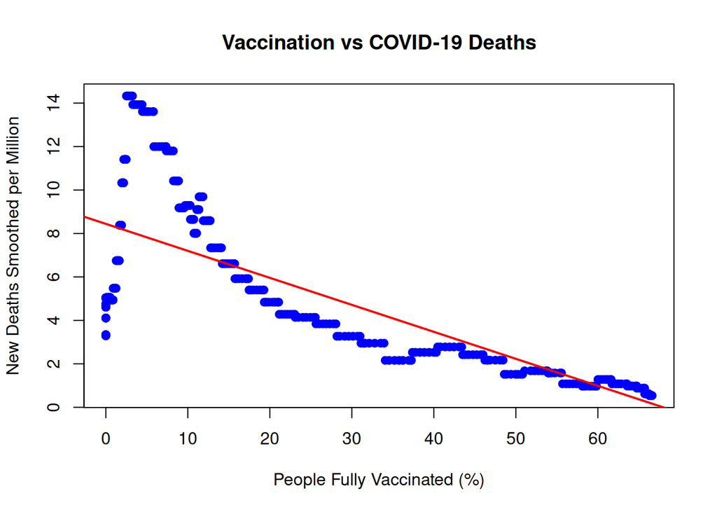

```r
plot(df_country$people_fully_vaccinated_per_hundred,
     df_country$new_deaths_smoothed_per_million,
     xlab = "People Fully Vaccinated (%)",
     ylab = "New Deaths Smoothed per Million",
     main = "Vaccination vs COVID-19 Deaths",
     pch = 19, col = "blue")

# Add regression line
abline(model, col = "red", lwd = 2)
```

Estimated coefficient is less than $0$ ($\approx -0.124$), p-value is significantly smaller than $0.01$ ($\approx <2e-16$). We reject $H_0$.

## Results

For the world-level data, the estimated slope coefficient for vaccination is negative and the p-value is far below $0.01$. Therefore, we reject $H_0$ and conclude that, in the aggregated global series, higher vaccination levels are statistically associated with lower death rates.

For all counties we got estimated coefficients less than 0 and small p-values. From this we cannot generalize results to all countries, but still we have some evidence suggesting that higher vaccination rates are associated with lower COVID-19 death rates in the analyzed sample, indicating a protective effect of vaccines in these contexts.

## Biases of the Model

The linear regression model used in the analysis is straightforward and easy to interpret, but it introduces several important biases. First, it assumes a strictly linear relationship between vaccination levels and death rates, which may not reflect the true dynamics of an epidemic. Second, the model treats observations as independent, while real-world time series has strong autocorrelation and temporal structure that violate this assumption. Third, the model does not control for key confounding factors such as number of cases, reporting practices, demographic differences, healthcare capacity, or government interventions. Ignoring these variables can lead to omitted‐variable bias and distort the estimated effect of vaccination. Additionally, this model is limited in that it can only test the hypothesis for a single country at a time. It does not provide a way to simultaneously analyze all countries, which restricts our ability to draw conclusions about global trends or compare countries directly. These limitations mean that the results should be interpreted cautiously, as the model captures only a simplified view of a complex epidemiological process.

## Ways to improve a model

### Multiple regression

One way to improve the model is to use multiple regression, where we include additional relevant predictors alongside vaccination. For example, we can control for the number of COVID-19 cases which has very great impact on number of cases. This allows the model to isolate the effect of vaccination on deaths more accurately, by accounting for other variables that also influence the outcome.

For instance next equation can be used:

$$Y_t = \beta_0 + \beta_1 X_t + \beta_2 Z_t + \epsilon$$

Where:  
$Y_t$ - `new_deaths_smoothed_per_million` on day $t$  
$X_t$ - `people_fully_vaccinated_per_hundred` on day $t$  
$Z_t$ - `new_cases_smoothed_per_million` on day $t$

### Adding lag

Another way to improve the model is to add a time lag between vaccination and its effect on deaths. Since vaccines do not produce immediate protection, the impact on mortality is typically observed after a delay of several weeks. By including a lagged version of the vaccination variable, the model can more accurately capture the delayed effect of vaccination on reducing deaths.

For instance next equation can be used:
$$Y_t = \beta_0 + \beta_1 X_{t-k} + \epsilon$$

Where:  
$Y_t$ – `new_deaths_smoothed_per_million` on day $t$  
$X_{t-k}$ – `people_fully_vaccinated_per_hundred` on day $t-k$, representing the vaccination level lagged by $k$ days

### Panel regression

Panel regression is one of the most robust methods for testing our hypothesis and is commonly used in real-world analysis with panel data. It allows us to analyze data across multiple countries and over time simultaneously. This method can control for unobserved country-specific effects, such as development level, average age, or geographic location. As a result, it provides more reliable estimates of the effect of vaccination on deaths.

To see the results from a panel regression model, we conducted a test using a fixed effects model, which accounts for both `people_fully_vaccinated_per_hundred` and `new_cases_smoothed_per_million`.

```r
model <- feols(
  new_deaths_smoothed_per_million ~
  people_fully_vaccinated_per_hundred + new_cases_smoothed_per_million |
  iso_code + date,
  data = df_interpolated
)

print(summary(model))
```

```
## OLS estimation, Dep. Var.: new_deaths_smoothed_per_million
## Observations: 68,255
## Fixed-effects: iso_code: 187,  date: 365
## Standard-errors: IID
##                                      Estimate Std. Error  t value  Pr(>|t|)
## people_fully_vaccinated_per_hundred -0.043196   0.001038 -41.6226 < 2.2e-16 ***
## new_cases_smoothed_per_million       0.007882   0.000055 144.2452 < 2.2e-16 ***
## ---
## Signif. codes:  0 '***' 0.001 '**' 0.01 '*' 0.05 '.' 0.1 ' ' 1
## RMSE: 3.18718     Adj. R2: 0.447339
##                 Within R2: 0.253402
```

The estimated coefficient for vaccination is less than $0$ and the p-value is extremely small, so we reject $H_0$. This supports the results obtained from our simple linear regression model.

Further discussion of the model mechanics or additional results will not be provided here, as it is quite complex and beyond the scope of this P&S course.

# Our second hypothesis

In the graph “Relationships between population age and COVID-19 mortality”, we noticed that countries with a higher percentage of people over 65 tend to have points further from the X-axis. Based on this observation, we formulated the following hypothesis to test whether this pattern occurred by chance or there is general trend.

$H_0$: The proportion of people over 65 in single country doesn’t affect COVID-19 death rates.

# Testing the second hypothesis

## Data preparation for testing the second hypothesis

For second hypothesis we have already prepared the data. Here we use the same data as we used while visualizing relationship between people over 65 and total deaths in the country. I will duplicate the code I used above to comment it:

```r
df <- read.csv("owid-covid-data.csv")
```

```r
df_hypothesis2 <- df %>%
  filter(!grepl("^OWID_", iso_code)) %>%

  group_by(location) %>%
  summarise(
    aged_65_older_mean = mean(aged_65_older, na.rm = TRUE),
    total_deaths_final = max(total_deaths_per_million, na.rm = TRUE)
  ) %>%

  filter(is.finite(total_deaths_final)) %>%
  filter(!is.na(aged_65_older_mean)) %>%
  filter(total_deaths_final > 0)
```

In this code we remove aggregate regions (keep only actual countries) as it was done during data preparation for the first hypothesis. Also we get rid of countries which doesn’t have reports about deaths caused by COVID-19: Turkmenistan, North Korea, Hong Kong, etc.

# Testing

## Linear regression

As for the first for second hypothesis we also use simple linear regression model based on data from each country. `total_deaths_final` - dependent variable and `aged_over_65` - independent.

Equation:

$$Y = b_0 + b_1 X + \epsilon$$

**Hypothesis:**

$H_0$: $b_1 = 0$.

$H_1$: $b_1 > 0$.

Estimator for coefficient b1, estimator for the sum of squared residuals, estimator for variance, test statistic under $H_0$ and critical region are calculated in the same way as for Hypothesis 1

As we mentioned earlier we are choosing maximal probability of type I error $\alpha=0.01$. If p-value of a test is smaller than $0.01$ we are rejecting $H_0$.

Our model is applied for all countries from the dataset which contain information about deaths of COVID-19.

### World

```r
model2 <- lm(total_deaths_final ~ aged_65_older_mean, data=df_hypothesis2)
summary(model2)
```

```
##
## Call:
## lm(formula = total_deaths_final ~ aged_65_older_mean, data = df_hypothesis2)
##
## Residuals:
##     Min      1Q  Median      3Q     Max
## -3549.6  -510.1  -297.4   590.6  5523.3
##
## Coefficients:
##                    Estimate Std. Error t value Pr(>|t|)
## (Intercept)          -25.08     130.84  -0.192    0.848
## aged_65_older_mean   154.24      12.31  12.526   <2e-16 ***
## ---
## Signif. codes:  0 '***' 0.001 '**' 0.01 '*' 0.05 '.' 0.1 ' ' 1
##
## Residual standard error: 1036 on 186 degrees of freedom
## Multiple R-squared:  0.4576, Adjusted R-squared:  0.4546
## F-statistic: 156.9 on 1 and 186 DF,  p-value: < 2.2e-16
```

### Visualization

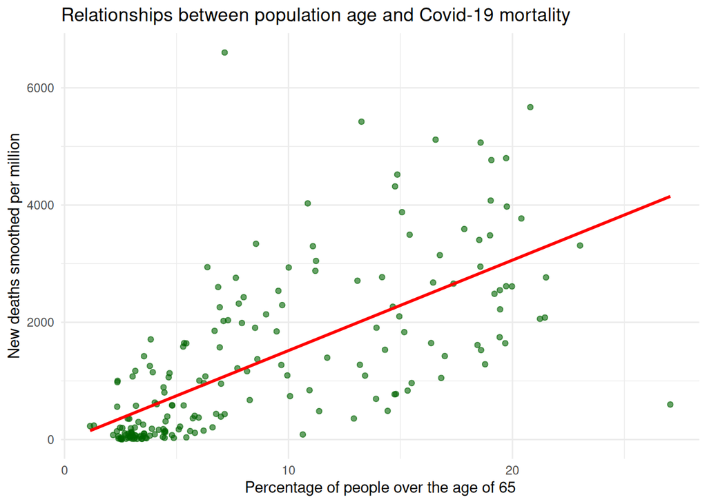

```r
ggplot(df_hypothesis2, aes(x = aged_65_older_mean, y = total_deaths_final)) +
  geom_point(alpha = 0.6, color = "darkgreen") +
  geom_smooth(method = "lm", color = "red", se = FALSE) +
  labs(
    title = "Relationships between population age and Covid-19 mortality",
    x = "Percentage of people over the age of 65",
    y = "New deaths smoothed per million"
  ) +
  theme_minimal()
```

## Results

For the world-level data, the estimated slope coefficient for elder people (over 65) $\approx 154$ and p-value is less than 0.01 that’s why we can reject the $H_0$ and conclude that, in the aggregated global series, higher percentage of people aged over 65 is statistically associated with higher death rates.

## Ways to improve a model

### Multiple regression

Instead of using one random variable Age ($X_1$), we can add other factors available in our dataset, such as `gdp_per_capita`, `population_density` and `people_fully_vaccinated_per_hundred`, etc.

For instance next equation can be used:

$$Y = b_0 + b_1 X_1 + b_2 X_2 + \epsilon$$

Where:  
$Y$ - `total_deaths_final` on the last day of observations  
$X_1$ - `aged_65_older`  
$X_2$ - `population_density`